# Programação

## 2022/2023, 1º semestre

### Trabalho Individual

> **Versão**: 1.0, 14/11/2022  
> **Prazo de entrega**: Sábado, 10/12/2022, às 23:59

Durante uma **conferência científica** são apresentados **artigos** que passam por um processo prévio de submissão e **revisão**. Como esse processo é moroso e burocrático, embora essencial para garantir a qualidade das apresentações e posteriores publicações, os organizadores de uma dada conferência decidiram automatizá-lo. Para isso começaram por escrever um conjunto de definições e requisitos para o sistema a desenvolver, que depois enviaram para a equipa de desenvolvimento. O resultado foi a seguinte lista de requisitos:

- Podem-se registar na conferência cientistas que farão parte da sua comissão técnica, i.e., que se encarregarão de rever os artigos que lhes forem atribuídos. A esses cientistas dá-se o nome de revisores.
- Dos revisores, neste caso, só é necessário conhecer o nome. Não se permitem nomes de revisores nulos (i.e., vazios).
- Não se pode registar na conferência mais do que um revisor com o mesmo nome.
- Podem-se registar na conferência artigos, que passarão por um processo de revisão. Estes artigos têm um título não-nulo e uma lista de nomes não-nulos de autores, contendo pelo menos um autor, não se permitindo repetições de nomes de autores.
- Não se pode registar na conferência mais do que um artigo com o mesmo título.
- Deve ser possível também registar na conferência um processo de revisão, ou simplesmente uma revisão. Uma revisão relaciona um revisor, identificado pelo nome, com um artigo, identificado pelo título. Uma revisão pode estar incompleta, o que significa que o revisor ainda não deu a sua opinião acerca do artigo, ou completa. Se estiver completa, é possível saber se o revisor aceitou ou rejeitou o artigo, e quais os seus comentários.
- Não é possível registar revisões repetidas, i.e., duas ou mais revisões do mesmo artigo pelo mesmo revisor.
- Deve ser possível indicar que um determinado revisor terminou a revisão de um determinado artigo, indicando se o aceitou ou não, e qual o seu comentário. Esta acção não pode ser repetida, i.e., se uma revisão está completa, não é possível completá-la de novo ou alterá-la.
- Um artigo só se considera revisto quando todas as revisões a ele associadas estiverem completas.
- Um artigo só é aceite se estiver revisto e tiver sido aceite por todas as revisões a ele associadas.
- Um artigo é considerado rejeitado se estiver revisto e se pelo menos uma das suas revisões o tiver rejeitado.
- Deve-se poder ver o estado actual da conferência, i.e., saber qual a lista de artigos aceites, incluindo as correspondentes revisões, qual a lista de artigos rejeitados, também incluindo as respectivas revisões, e qual a lista de artigos ainda por rever, de novo incluindo as respectivas revisões.
- Deve ser possível saber a média de artigos revistos por revisor e a média de revisores por artigo. Deverá ser possível saber quantos revisores fizeram uma revisão, quantos fizeram duas revisões, etc. até ao número máximo de revisões realizadas por um revisor.

**Observação:** Os estudantes podem partilhar e/ou trocar ideias entre si, sobre os trabalhos e/ou resolução dos mesmos. No entanto, o trabalho entregue deve corresponder ao esforço individual de cada estudante. *O projeto é individual, e em nenhum caso deve ser copiado código que será entregue*. A deteção de código copiado será realizada por software especializado bastante sofisticado. Casos de plágio óbvio serão penalizados com a anulação do projeto, o que implica a reprovação à Unidade Curricular (UC). Adicionalmente, a situação será reportada à Comissão Pedagógica da ISTA e ao Conselho Pedagógico do Iscte, de acordo com a *Política em Caso de Fraude descrita no final deste documento*. Serão penalizados da mesma forma tanto os estudantes que fornecem código como os que copiam código de outros.

## T1: Classe *Artigo* (`Paper`)

Deve ser desenvolvida uma classe de objetos que representa o conceito de artigo.

Um artigo, tal como indicado, tem um título e uma lista de autores. Ao criar objetos deste tipo, é obrigatório indicar o título e a lista de autores representados pelos seus nomes. Após a criação de um objeto deste tipo não deverá ser possível alterar o título, nem a lista de autores. A lista de autores tem de ter, pelo menos, um autor e não podem existir autores com o mesmo nome.

Um objeto deste tipo deverá ter as seguintes funcionalidades:

- deverá ser possível obter qualquer um dos atributos;
- deverá ser possível converter um artigo numa cadeia de caracteres, permitindo assim mostrar os seus detalhes com base na instrução `print()`;
- deverá ser possível comparar artigos usando o operador `==`. Dois artigos são iguais quando os seus títulos são iguais.

## T2: Classe *Revisão* (`Review`)

Deve ser desenvolvida uma classe de objetos que representa o conceito de revisão.

Uma revisão, tal como indicado, associa um revisor, representado pelo seu nome, a um artigo, também através do seu nome. Assim, ao criar objetos deste tipo é obrigatório indicar o nome do revisor e o título do artigo. Após a criação de um objeto não deverá ser possível alterar nem o o nome do revisor nem o título do artigo.

Um objeto deste tipo deverá ter as seguintes funcionalidades:

- deverá ser possível registar o resultado da revisão, i.e., se o artigo foi aceite e qual o comentário do revisor;
- deverá ser possível obter o nome e o título do artigo;
- deverá ser possível saber se a revisão já está completa;
- deverá ser possível saber qual o comentário do revisor, caso a revisão já esteja completa;
- deverá ser possível saber se o artigo foi aceite, caso a revisão já esteja completa;
- deverá ser possível converter uma revisão numa cadeia de caracteres, permitindo assim mostrar os seus detalhes com base na instrução `print()`.

## T3: Classe *Conferência* (`Conference`)

Deve ser desenvolvida uma classe de objetos que representa o conceito de conferência.

Uma conferência deve possuir os registos dos revisores, artigos e revisões que os relacionam. Quando um objeto deste é construído deve ser criada uma conferência sem artigos, sem revisores e sem revisões.

Um objeto deste tipo deverá ter as seguintes funcionalidades:

- registar um novo artigo, cujo título não pode constar já na conferência;
- registar um novo revisor na conferência, dado o seu nome. O nome do revisor não pode ser repetido;
- registar a revisão de um artigo com um dado título por um revisor com um dado nome. Não pode existir já na conferência uma outra revisão do mesmo artigo pelo mesmo revisor;
- registar o resultado de uma revisão de um artigo com um dado título por um revisor com um dado nome. Tem de haver já uma revisão desse artigo por esse revisor, revisão essa que não pode estar terminada. O resultado indica se o artigo foi aceite (ou não) e um comentário;
- obter um artigo dado o seu título;
- saber o número de artigos na conferência;
- saber o número de revisores na conferência;
- saber o número de revisões em falta (i.e., incompletas) na conferência;
- saber se está registado na conferência um artigo com um dado título;
- saber se está registado na conferência um revisor com um dado nome;
- saber se está registada na conferência a revisão de um artigo com um dado título por um revisor com um dado nome;
- saber se já há na conferência uma revisão terminada de um artigo com um dado título por um revisor com um dado nome;
- saber se foi aceite um artigo com um dado título por um revisor com um dado nome;
- saber se um artigo foi **aprovado**. I.e., se já foram terminadas todas as suas revisões e todas tiveram aceite como resultado. Um artigo sem quaisquer revisões considera-se não aprovado;
- saber se um artigo foi **reprovado**. I.e., se já foram terminadas todas as suas revisões e houve pelo menos uma rejeição;
- saber se um artigo está por rever, i.e., se alguma das suas revisões está ainda por completar;
- saber se há artigos sem revisões associadas;
- mostrar as revisões de um artigo com um dado título;
- mostrar o estado da conferência.

## T4: Programa

Pretende-se fazer um programa que, com base num objeto da classe *Conferência*, faça a gestão da plataforma. O programa deverá apresentar um menu com as seguintes opções:

1. Introduzir novo artigo;
2. Introduzir novo revisor;
3. Introduzir nova revisão;
4. Introduzir resultado de revisão;
5. Estado da conferência;
6. Estatísticas;
7. Sair.

O menu encontra-se em ciclo, permitindo realizar as várias operações múltiplas vezes, até que o utilizador escolha a opção 7, que permite sair do programa. Cada uma das opções anteriores, invoca uma das funcionalidades descritas na tarefa T3. Algumas das opções exigem que seja solicitada informação ao utilizador por forma a que se possa passar essa informação como argumento dos métodos correspondentes. Sempre que o programa termina, deve pedir ao utilizador o nome de um ficheiro para guardar a lista de artigos da conferência e gravar essa informação nesse ficheiro. O formato do ficheiro deve ser o seguinte:

```
número_de_artigos
título_do_artigo_1;número_de_autores;autor_1;...
```

Para o exemplo abaixo, o ficheiro 'conf.txt' deveria ter o seguinte conteúdo:

```
2
Título1;1;Autor1
Título2;2;Autor1;Autor2
```

Abaixo está um exemplo de interação.

> 1. Introduzir novo artigo.
> 2. Introduzir novo revisor.
> 3. Introduzir nova revisão.
> 4. Introduzir resultado de revisão.
> 5. Estado da conferência.
> 6. Estatísticas.
> 7. Sair.  
>    Introduza a sua opção: 1

>    ```
>     Introduza o título: Título1
>     Introduza o número de autores do artigo: 1
>     Introduza o autor 1: Autor1
>    ```

> 1. Introduzir novo artigo.
> 2. Introduzir novo revisor.
> 3. Introduzir nova revisão.
> 4. Introduzir resultado de revisão.
> 5. Estado da conferência.
> 6. Estatísticas.
> 7. Sair.  
>    Introduza a sua opção: 1

>    ```
>     Introduza o título: Título1
>     Título já existe na conferência.
>    ```

> 1. Introduzir novo artigo.
> 2. Introduzir novo revisor.
> 3. Introduzir nova revisão.
> 4. Introduzir resultado de revisão.
> 5. Estado da conferência.
> 6. Estatísticas.
> 7. Sair.  
>    Introduza a sua opção: 1

>    ```
>     Introduza o título: Título2
>     Introduza o número de autores do artigo: 0
>     Introduza o número de autores do artigo: 2
>     Introduza o autor 1: Autor1
>     Introduza o autor 2: Autor2
>    ```

> 1. Introduzir novo artigo.
> 2. Introduzir novo revisor.
> 3. Introduzir nova revisão.
> 4. Introduzir resultado de revisão.
> 5. Estado da conferência.
> 6. Estatísticas.
> 7. Sair.  
>    Introduza a sua opção: 2

>    ```
>     Introduza o nome: Revisor1
>    ```

> 1. Introduzir novo artigo.
> 2. Introduzir novo revisor.
> 3. Introduzir nova revisão.
> 4. Introduzir resultado de revisão.
> 5. Estado da conferência.
> 6. Estatísticas.
> 7. Sair.  
>    Introduza a sua opção: 2

>    ```
>     Introduza o nome: Revisor2
>    ```

> 1. Introduzir novo artigo.
> 2. Introduzir novo revisor.
> 3. Introduzir nova revisão.
> 4. Introduzir resultado de revisão.
> 5. Estado da conferência.
> 6. Estatísticas.
> 7. Sair.  
>    Introduza a sua opção: 3

>    ```
>     Introduza título do artigo : Título1
>     Introduza o nome do revisor: Revisor1
>    ```

> 1. Introduzir novo artigo.
> 2. Introduzir novo revisor.
> 3. Introduzir nova revisão.
> 4. Introduzir resultado de revisão.
> 5. Estado da conferência.
> 6. Estatísticas.
> 7. Sair.  
>    Introduza a sua opção: 3

>    ```
>     Introduza título do artigo: Título2
>     Introduza o nome do revisor: Revisor2
>    ```

> 1. Introduzir novo artigo.
> 2. Introduzir novo revisor.
> 3. Introduzir nova revisão.
> 4. Introduzir resultado de revisão.
> 5. Estado da conferência.
> 6. Estatísticas.
> 7. Sair.  
>    Introduza a sua opção: 3

>    ```
>     Introduza título do artigo: Título2
>     Introduza o nome do revisor: Revisor3
>     Revisor não existe na conferência.
>    ```

> 1. Introduzir novo artigo.
> 2. Introduzir novo revisor.
> 3. Introduzir nova revisão.
> 4. Introduzir resultado de revisão.
> 5. Estado da conferência.
> 6. Estatísticas.
> 7. Sair.  
>    Introduza a sua opção: 2

>    ```
>     Introduza o nome: Revisor3
>    ```

> 1. Introduzir novo artigo.
> 2. Introduzir novo revisor.
> 3. Introduzir nova revisão.
> 4. Introduzir resultado de revisão.
> 5. Estado da conferência.
> 6. Estatísticas.
> 7. Sair.  
>    Introduza a sua opção: 3

>    ```
>     Introduza título do artigo: Título2
>     Introduza o nome do revisor: Revisor3
>    ```

> 1. Introduzir novo artigo.
> 2. Introduzir novo revisor.
> 3. Introduzir nova revisão.
> 4. Introduzir resultado de revisão.
> 5. Estado da conferência.
> 6. Estatísticas.
> 7. Sair.  
>    Introduza a sua opção: 3

>    ```
>     Introduza título do artigo: Título1
>     Introduza o nome do revisor: Revisor1
>     Esse revisor já está encarregado desse
>     artigo.
>    ```

> 1. Introduzir novo artigo.
> 2. Introduzir novo revisor.
> 3. Introduzir nova revisão.
> 4. Introduzir resultado de revisão.
> 5. Estado da conferência.
> 6. Estatísticas.
> 7. Sair.  
>    Introduza a sua opção: 4

>    ```
>     Introduza título do artigo: Título1
>     Introduza o nome do revisor: Revisor1
>     Introduza o resultado da revisão
>     ([A]ceite/[R]ejeitado): a
>     Introduza o comentário de revisão:
>     Comentário1
>    ```

> 1. Introduzir novo artigo.
> 2. Introduzir novo revisor.
> 3. Introduzir nova revisão.
> 4. Introduzir resultado de revisão.
> 5. Estado da conferência.
> 6. Estatísticas.
> 7. Sair.  
>    Introduza a sua opção: 4

>    ```
>     Introduza título do artigo: Título2
>     Introduza o nome do revisor: Revisor2
>     Introduza o resultado da revisão
>     ([A]ceite/[R]ejeitado): r
>     Introduza o comentário de revisão:
>     Comentário2
>    ```

> 1. Introduzir novo artigo.
> 2. Introduzir novo revisor.
> 3. Introduzir nova revisão.
> 4. Introduzir resultado de revisão.
> 5. Estado da conferência.
> 6. Estatísticas.
> 7. Sair.  
>    Introduza a sua opção: 5

>    ```
>     *** Artigos aceites:
>     Autor1. "Título1".
>     . Revisor1: aceite, Comentário1.
>     *** Artigos rejeitados:
>     *** Artigos por rever:
>     Autor1 e Autor2. "Título2".
>     . Revisor2: rejeitado, Comentário2.
>     . Revisor3: incompleta.
>    ```

> 1. Introduzir novo artigo.
> 2. Introduzir novo revisor.
> 3. Introduzir nova revisão.
> 4. Introduzir resultado de revisão.
> 5. Estado da conferência.
> 6. Estatísticas.
> 7. Sair.  
>    Introduza a sua opção: 6

>    ```
>     Média de autores por artigo: 1.5
>     Média de artigos por revisor: 1
>     Média de revisores por artigo: 1.5
>    ```

>    == **Gráfico: Histograma de revisões** ==
> 1. Introduzir novo artigo.
> 2. Introduzir novo revisor.
> 3. Introduzir nova revisão.
> 4. Introduzir resultado de revisão.
> 5. Estado da conferência.
> 6. Estatísticas.
> 7. Sair.  
>    Introduza a sua opção: 7

>    ```
>     Nome do ficheiro: conf.txt
>    ```

## T5: Estatísticas

Deverá ser possível obter diferentes estatísticas sobre o processo de revisão de uma conferência. Nomeadamente, deverá ser possível obter:

- a média de autores por artigo;
- a média de artigos revistos por revisor;
- a média de revisores por artigo;
- quantos revisores fizeram uma revisão, quantos fizeram duas revisões, etc. até ao número máximo de revisões realizadas por um revisor.

Para esta última estatística, deve criar um gráfico que melhor ilustra a estatística pretendida (um histograma). O código abaixo ilustra como tal pode ser implementado.

**Observação:** Pode ser necessário instalar as bibliotecas *numpy* e *matplotlib*.

```
[[2 1]
 [3 5]
 [4 3]]
```

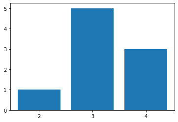

```python
import numpy
import matplotlib.pyplot as plt

mydata = numpy.zeros([3, 2], int)
mydata[0, 0] = 2 # Duas revisões
mydata[0, 1] = 1 # Um revisor
mydata[1, 0] = 3 # Três revisões
mydata[1, 1] = 5 # Cinco revisores
mydata[2, 0] = 4 # Quatro revisões
mydata[2, 1] = 3 # Três revisores

print(mydata)

labels = [str(i) for i in mydata[:,0]]
plt.bar(labels, mydata[:,1])
plt.show()
```

## Entrega e Avaliação

O trabalho deverá ser entregue através do moodle. Cada estudante deverá submeter um ficheiro zip com o código e ficheiros adicionais que possa ter usado no âmbito do trabalho.

O projeto será classificado numa escala de 0 a 20 valores, mas a nota atribuída será sempre um múltiplo de 2, por exemplo, 8, 10, 12, 14, 16, 18 ou 20. O peso de cada uma das tarefas na nota é o seguinte: T1: 3v, T2: 5v, T3: 7v, T4: 2v, T5: 3v.

O projeto será inicialmente avaliado em termos funcionais, i.e., se as funções e procedimentos produzem os resultados esperados e os objetos dos tipos das classes a desenvolver têm o comportamento esperado, independentemente da forma como estão implementados. Desta avaliação resultará uma classificação, que poderá sofrer uma penalização em função da qualidade do código. Os estudantes poderão obter *feedback* junto dos professores sobre o progresso do projeto e qualidade do código e deverão seguir as recomendações dadas.

### Política em caso de fraude

Os estudantes podem partilhar e/ou trocar ideias entre si sobre os trabalhos e/ou resolução dos mesmos. No entanto, o trabalho entregue deve corresponder ao esforço individual de cada estudante. São consideradas fraudes as seguintes situações:

- trabalho parcialmente copiado;
- facilitar a copia através da partilha de ficheiros;
- utilizar material alheio sem referir a sua fonte.

Em caso de deteção de algum tipo de fraude, os trabalhos em questão não serão avaliados, sendo enviados à Comissão Pedagógica ou ao Conselho Pedagógico, consoante a gravidade da situação, que decidirão a sanção a aplicar aos estudantes envolvidos. Serão utilizadas as ferramentas *Moss* e *SafeAssign* para detecção automática de cópias.

Recorda-se ainda que o Anexo I do Código de Conduta Académica, publicado a a 25 de Janeiro de 2016 em Diário da Republica, 2ª Série, nº 16, indica no seu ponto 2 que:

> Quando um trabalho ou outro elemento de avaliação apresentar um nível de coincidência elevado com outros trabalhos (percentagem de coincidência com outras fontes reportada no relatório que o referido software produz), cabe ao docente da UC, orientador ou a qualquer elemento do júri, após a análise qualitativa desse relatório, e em caso de se confirmar a suspeita de plágio, desencadear o respetivo procedimento disciplinar, de acordo com o Regulamento Disciplinar de Discentes do ISCTE - Instituto Universitário de Lisboa, aprovado pela deliberação n.o 2246/2010, de 6 de dezembro.

O ponto 2.1 desse mesmo anexo indica ainda que:

> No âmbito do Regulamento Disciplinar de Discentes do ISCTE-IUL, são definidas as sanções disciplinares aplicáveis e os seus efeitos, podendo estas variar entre a advertência e a interdição da frequência de atividades escolares no ISCTE-IUL até cinco anos.